# Car Price Prediction model. Miango-Ujah Madaki Umar

```python
import numpy as np
import pandas as pd
import matplotlib.pyplot as plt
import seaborn as sns
%matplotlib inline
cp = pd.read_csv('CarPrice_data.csv')
```

```python
import warnings
warnings.filterwarnings('ignore')
```

```python
cp.head(10)
```

|  | car_ID | symboling | CarName | fueltype | aspiration | doornumber | carbody | drivewheel | enginelocation | wheelbase | ... | enginesize | fuelsystem | boreratio | stroke | compressionratio | horsepower | peakrpm | citympg | highwaympg | price |
| --- | --- | --- | --- | --- | --- | --- | --- | --- | --- | --- | --- | --- | --- | --- | --- | --- | --- | --- | --- | --- | --- |
| 0 | 1 | 3 | alfa-romero giulia | gas | std | two | convertible | rwd | front | 88.6 | ... | 130 | mpfi | 3.47 | 2.68 | 9.0 | 111 | 5000 | 21 | 27 | 13495.000 |
| 1 | 2 | 3 | alfa-romero stelvio | gas | std | two | convertible | rwd | front | 88.6 | ... | 130 | mpfi | 3.47 | 2.68 | 9.0 | 111 | 5000 | 21 | 27 | 16500.000 |
| 2 | 3 | 1 | alfa-romero Quadrifoglio | gas | std | two | hatchback | rwd | front | 94.5 | ... | 152 | mpfi | 2.68 | 3.47 | 9.0 | 154 | 5000 | 19 | 26 | 16500.000 |
| 3 | 4 | 2 | audi 100 ls | gas | std | four | sedan | fwd | front | 99.8 | ... | 109 | mpfi | 3.19 | 3.40 | 10.0 | 102 | 5500 | 24 | 30 | 13950.000 |
| 4 | 5 | 2 | audi 100ls | gas | std | four | sedan | 4wd | front | 99.4 | ... | 136 | mpfi | 3.19 | 3.40 | 8.0 | 115 | 5500 | 18 | 22 | 17450.000 |
| 5 | 6 | 2 | audi fox | gas | std | two | sedan | fwd | front | 99.8 | ... | 136 | mpfi | 3.19 | 3.40 | 8.5 | 110 | 5500 | 19 | 25 | 15250.000 |
| 6 | 7 | 1 | audi 100ls | gas | std | four | sedan | fwd | front | 105.8 | ... | 136 | mpfi | 3.19 | 3.40 | 8.5 | 110 | 5500 | 19 | 25 | 17710.000 |
| 7 | 8 | 1 | audi 5000 | gas | std | four | wagon | fwd | front | 105.8 | ... | 136 | mpfi | 3.19 | 3.40 | 8.5 | 110 | 5500 | 19 | 25 | 18920.000 |
| 8 | 9 | 1 | audi 4000 | gas | turbo | four | sedan | fwd | front | 105.8 | ... | 131 | mpfi | 3.13 | 3.40 | 8.3 | 140 | 5500 | 17 | 20 | 23875.000 |
| 9 | 10 | 0 | audi 5000s (diesel) | gas | turbo | two | hatchback | 4wd | front | 99.5 | ... | 131 | mpfi | 3.13 | 3.40 | 7.0 | 160 | 5500 | 16 | 22 | 17859.167 |

10 rows × 26 columns

```python
cp.isnull().sum()
```

```
car_ID              0
symboling           0
CarName             0
fueltype            0
aspiration          0
doornumber          0
carbody             0
drivewheel          0
enginelocation      0
wheelbase           0
carlength           0
carwidth            0
carheight           0
curbweight          0
enginetype          0
cylindernumber      0
enginesize          0
fuelsystem          0
boreratio           0
stroke              0
compressionratio    0
horsepower          0
peakrpm             0
citympg             0
highwaympg          0
price               0
dtype: int64
```

# EDA

```python
#from pandas_profiling import ProfileReport
#profile = ProfileReport(cp)
#profile
```

```python
cp.columns
```

```
Index(['car_ID', 'symboling', 'CarName', 'fueltype', 'aspiration',
       'doornumber', 'carbody', 'drivewheel', 'enginelocation', 'wheelbase',
       'carlength', 'carwidth', 'carheight', 'curbweight', 'enginetype',
       'cylindernumber', 'enginesize', 'fuelsystem', 'boreratio', 'stroke',
       'compressionratio', 'horsepower', 'peakrpm', 'citympg', 'highwaympg',
       'price'],
      dtype='object')
```

# UNIVARIATE ANALYSIS

```
[Text(0.5, 1.0, 'Prices')]
```

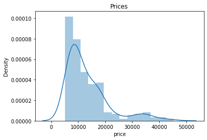

```python
sns.distplot(cp['price']).set(title= 'Prices')
```

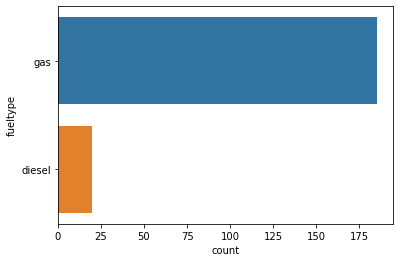

```python
#Univariate analyis for most used fueltype
sns.countplot(y='fueltype', data=cp)
```

### Observation

Most of the cars use gas

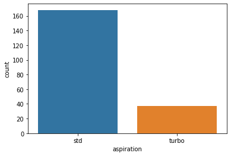

```python
sns.countplot(x='aspiration',data=cp )
```

### Observation

Most of the cars have naturally aspirated engines

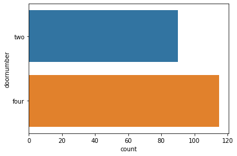

```python
#Univariate analysis for the number of doors
sns.countplot(y='doornumber', data=cp)
```

### Observation

Most of the cars have 4 doors

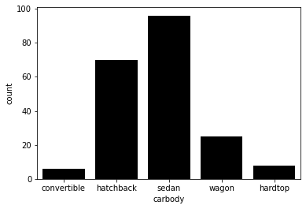

```python
#Univariate analysis for carbody types
sns.countplot(x='carbody', data=cp, color='black')
```

### Observation

Most of the car bodies are of sedan type, while the lowest car bodies are convertible

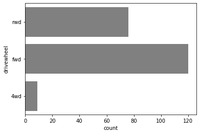

```python
#Univariate analysis for drivewheel type
sns.countplot(y= 'drivewheel', data = cp, color='gray')
```

### Observation

Most for the cars are front-wheel drives, while the lowest are four-wheel drives

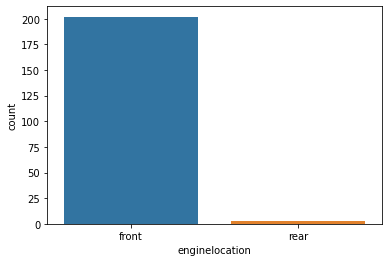

```python
#Univariate analysis for enginelocation
sns.countplot(x= 'enginelocation', data=cp)
```

### Observation

Most of the cars have their engines located at the front

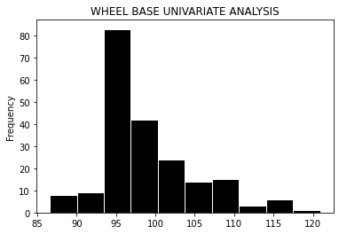

```python
#Univariate analysis for wheelbase
cp['wheelbase'].plot.hist(color='black', edgecolor='white', title= 'WHEEL BASE UNIVARIATE ANALYSIS')
```

### Observation

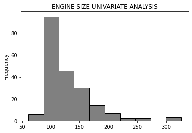

```python
#Univariate analysis for enginesize
cp['enginesize'].plot.hist(color='gray', edgecolor='black', title= 'ENGINE SIZE UNIVARIATE ANALYSIS')
```

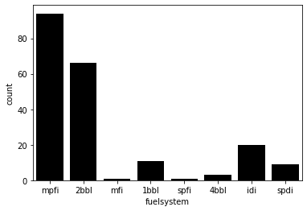

```python
#Univariate analysis for fuelsystem
sns.countplot(x='fuelsystem', data=cp, color= 'black')
```

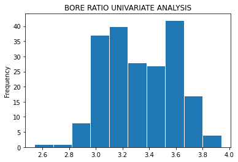

```python
#Univariate analysis for bore ratio
cp['boreratio'].plot.hist(edgecolor='white', title='BORE RATIO UNIVARIATE ANALYSIS')
```

### Observation

Most of the cars have a boreratio of 3.6

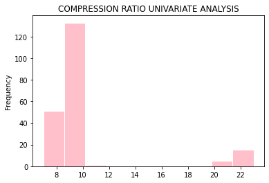

```python
#Univariate analysis for compression ratio
cp['compressionratio'].plot.hist(color='pink',edgecolor='white', title= 'COMPRESSION RATIO UNIVARIATE ANALYSIS')
```

### Observation

Most of the cars have a petrol engine compression ratio of 10

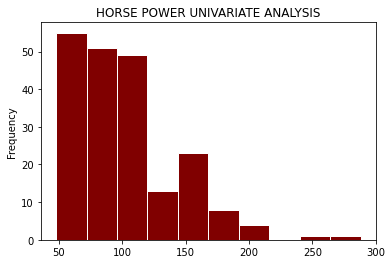

```python
#Univariate analysis for horsepower
cp['horsepower'].plot.hist(color='maroon', edgecolor='white', title= 'HORSE POWER UNIVARIATE ANALYSIS')
```

### Observation

Most of the cars have horsepower between the range of 50-99

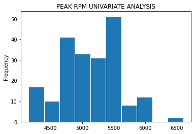

```python
#Univariate analysis for peak rpm
cp['peakrpm'].plot.hist(edgecolor='white', title = 'PEAK RPM UNIVARIATE ANALYSIS')
```

### Observation

Most of the cars have a peak rpm of 5500

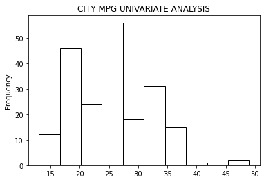

```python
#Univariate analysis of city mpg
cp['citympg'].plot.hist(color='white', edgecolor= 'black', title= 'CITY MPG UNIVARIATE ANALYSIS')
```

### Observation

Most of the cars have a city mpg between 25-29

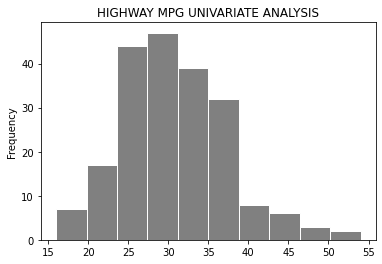

```python
#Univariate analysis of highway mpg
cp['highwaympg'].plot.hist(color='gray', edgecolor='white', title= 'HIGHWAY MPG UNIVARIATE ANALYSIS')
```

### Observation

Most of the cars have a highway mpg of 30

# BIVARIATE ANALYSIS

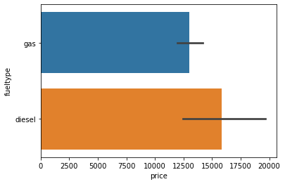

```python
#Bivariate analysis for fueltype and price
sns.barplot(x='price', y='fueltype', data=cp)
```

### Observation

Cars that use diesel have a higher price than those that use gas

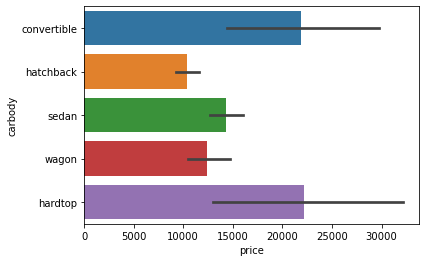

```python
#Bivariate analysis for carbody and price
sns.barplot(x= 'price', y='carbody', data=cp)
```

### Observation

Convertible cars and hardtop cars have the highest prices, while hatchback cars have the lowest price

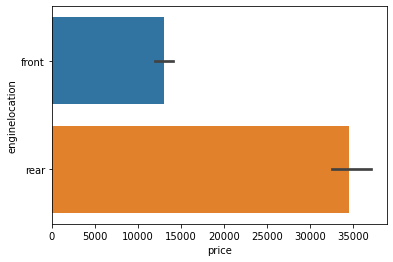

```python
#Bivariate analysis for engine location and price
sns.barplot(x= 'price', y= 'enginelocation', data=cp)
```

### Observation

Cars with rear engines have a higher price than those with front engines

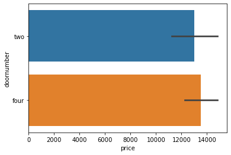

```python
#Bivariate analysis for price and doornumber
sns.barplot(x='price', y='doornumber', data=cp)
```

### Observation

Cars with 4 doors have a higher price than those with 2 doors

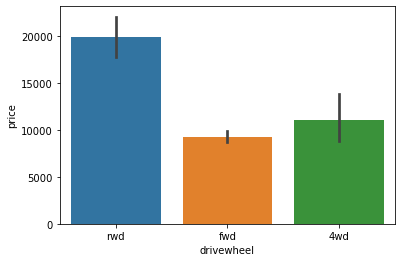

```python
#Bivariate analysis for price and drivewheel
sns.barplot(x='drivewheel', y= 'price', data=cp)
```

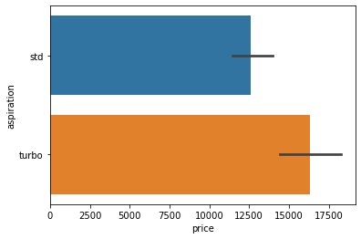

```python
#Bivariate analysis for aspiration and price
sns.barplot(y='aspiration', x= 'price', data=cp)
```

### Observation

Cars with turbo engines have a higher price than those with naturally aspirated engines

# MULTIVARIATE ANALYIS

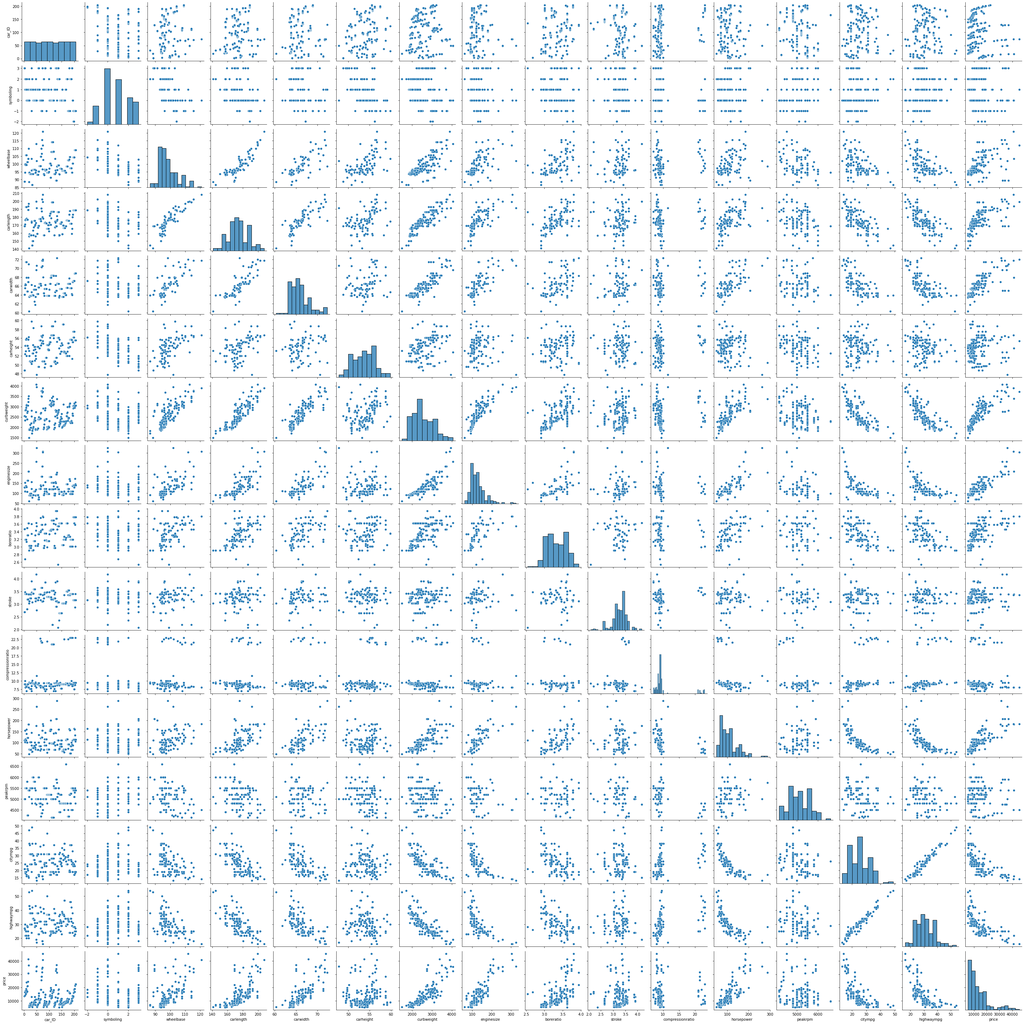

```python
sns.pairplot(cp)
```

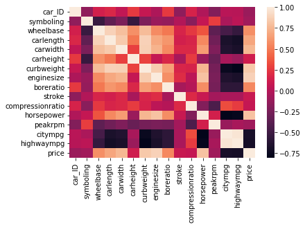

```python
sns.heatmap(cp.corr())
```

```python
cp.columns
```

```
Index(['car_ID', 'symboling', 'CarName', 'fueltype', 'aspiration',
       'doornumber', 'carbody', 'drivewheel', 'enginelocation', 'wheelbase',
       'carlength', 'carwidth', 'carheight', 'curbweight', 'enginetype',
       'cylindernumber', 'enginesize', 'fuelsystem', 'boreratio', 'stroke',
       'compressionratio', 'horsepower', 'peakrpm', 'citympg', 'highwaympg',
       'price'],
      dtype='object')
```

```python
cp.corr()
```

|  | car_ID | symboling | wheelbase | carlength | carwidth | carheight | curbweight | enginesize | boreratio | stroke | compressionratio | horsepower | peakrpm | citympg | highwaympg | price |
| --- | --- | --- | --- | --- | --- | --- | --- | --- | --- | --- | --- | --- | --- | --- | --- | --- |
| car_ID | 1.000000 | -0.151621 | 0.129729 | 0.170636 | 0.052387 | 0.255960 | 0.071962 | -0.033930 | 0.260064 | -0.160824 | 0.150276 | -0.015006 | -0.203789 | 0.015940 | 0.011255 | -0.109093 |
| symboling | -0.151621 | 1.000000 | -0.531954 | -0.357612 | -0.232919 | -0.541038 | -0.227691 | -0.105790 | -0.130051 | -0.008735 | -0.178515 | 0.070873 | 0.273606 | -0.035823 | 0.034606 | -0.079978 |
| wheelbase | 0.129729 | -0.531954 | 1.000000 | 0.874587 | 0.795144 | 0.589435 | 0.776386 | 0.569329 | 0.488750 | 0.160959 | 0.249786 | 0.353294 | -0.360469 | -0.470414 | -0.544082 | 0.577816 |
| carlength | 0.170636 | -0.357612 | 0.874587 | 1.000000 | 0.841118 | 0.491029 | 0.877728 | 0.683360 | 0.606454 | 0.129533 | 0.158414 | 0.552623 | -0.287242 | -0.670909 | -0.704662 | 0.682920 |
| carwidth | 0.052387 | -0.232919 | 0.795144 | 0.841118 | 1.000000 | 0.279210 | 0.867032 | 0.735433 | 0.559150 | 0.182942 | 0.181129 | 0.640732 | -0.220012 | -0.642704 | -0.677218 | 0.759325 |
| carheight | 0.255960 | -0.541038 | 0.589435 | 0.491029 | 0.279210 | 1.000000 | 0.295572 | 0.067149 | 0.171071 | -0.055307 | 0.261214 | -0.108802 | -0.320411 | -0.048640 | -0.107358 | 0.119336 |
| curbweight | 0.071962 | -0.227691 | 0.776386 | 0.877728 | 0.867032 | 0.295572 | 1.000000 | 0.850594 | 0.648480 | 0.168790 | 0.151362 | 0.750739 | -0.266243 | -0.757414 | -0.797465 | 0.835305 |
| enginesize | -0.033930 | -0.105790 | 0.569329 | 0.683360 | 0.735433 | 0.067149 | 0.850594 | 1.000000 | 0.583774 | 0.203129 | 0.028971 | 0.809769 | -0.244660 | -0.653658 | -0.677470 | 0.874145 |
| boreratio | 0.260064 | -0.130051 | 0.488750 | 0.606454 | 0.559150 | 0.171071 | 0.648480 | 0.583774 | 1.000000 | -0.055909 | 0.005197 | 0.573677 | -0.254976 | -0.584532 | -0.587012 | 0.553173 |
| stroke | -0.160824 | -0.008735 | 0.160959 | 0.129533 | 0.182942 | -0.055307 | 0.168790 | 0.203129 | -0.055909 | 1.000000 | 0.186110 | 0.080940 | -0.067964 | -0.042145 | -0.043931 | 0.079443 |
| compressionratio | 0.150276 | -0.178515 | 0.249786 | 0.158414 | 0.181129 | 0.261214 | 0.151362 | 0.028971 | 0.005197 | 0.186110 | 1.000000 | -0.204326 | -0.435741 | 0.324701 | 0.265201 | 0.067984 |
| horsepower | -0.015006 | 0.070873 | 0.353294 | 0.552623 | 0.640732 | -0.108802 | 0.750739 | 0.809769 | 0.573677 | 0.080940 | -0.204326 | 1.000000 | 0.131073 | -0.801456 | -0.770544 | 0.808139 |
| peakrpm | -0.203789 | 0.273606 | -0.360469 | -0.287242 | -0.220012 | -0.320411 | -0.266243 | -0.244660 | -0.254976 | -0.067964 | -0.435741 | 0.131073 | 1.000000 | -0.113544 | -0.054275 | -0.085267 |
| citympg | 0.015940 | -0.035823 | -0.470414 | -0.670909 | -0.642704 | -0.048640 | -0.757414 | -0.653658 | -0.584532 | -0.042145 | 0.324701 | -0.801456 | -0.113544 | 1.000000 | 0.971337 | -0.685751 |
| highwaympg | 0.011255 | 0.034606 | -0.544082 | -0.704662 | -0.677218 | -0.107358 | -0.797465 | -0.677470 | -0.587012 | -0.043931 | 0.265201 | -0.770544 | -0.054275 | 0.971337 | 1.000000 | -0.697599 |
| price | -0.109093 | -0.079978 | 0.577816 | 0.682920 | 0.759325 | 0.119336 | 0.835305 | 0.874145 | 0.553173 | 0.079443 | 0.067984 | 0.808139 | -0.085267 | -0.685751 | -0.697599 | 1.000000 |

# PREPARING DATA FOR MODELLING

```python
#pd.get_dummies(columns=['CarName','fueltype', 'aspiration','doornumber', 'carbody', 'drivewheel','enginelocation','enginetype', 'cylindernumber'], data=cp)
```

```python
x= cp[['CarName','fueltype', 'aspiration', 'carbody' ,'drivewheel','enginelocation', 'fuelsystem','enginetype', 'cylindernumber' ]]
y= cp['price']
```

```python
x = pd.get_dummies(columns=['CarName','fueltype', 'aspiration','doornumber', 'carbody', 'drivewheel','enginelocation','enginetype', 'cylindernumber', 'fuelsystem'], data=cp)
```

```python
from sklearn.preprocessing import StandardScaler
```

```python
scaler = StandardScaler()
x = scaler.fit_transform(x)
```

```python
from sklearn.model_selection import train_test_split
```

```python
x_test, x_train, y_test, y_train =  train_test_split(x,y,test_size=0.4,random_state=50)
```

```python
from sklearn.linear_model import LinearRegression
```

```python
model = LinearRegression()
model.fit(x_train,y_train)
```

```
LinearRegression()
```

```python
print(model.intercept_)
print(model.coef_)
```

[output not shown]

```python
predictions = model.predict(x_test)
```

```python
from sklearn.metrics import r2_score,mean_absolute_error,mean_squared_error
```

```python
score = r2_score(predictions,y_test)
score
```

```
0.8807402976168197
```

```python
mean_absolute_error(predictions,y_test)
```

```
1751.414171030234
```

```python
mean_squared_error(predictions,y_test)
```

```
5464446.466636364
```

```python
np.sqrt(mean_squared_error(predictions,y_test))
```

```
2337.615551504645
```